# Iniciação ao RMarkdown

[figure not shown]

# Introdução

“Instead of imagining that our main task is to instruct a computer what to do, let us concentrate rather on explaining to humans what we want the computer to do.”

Donald Knuth

*Markdown* é uma linguagem de marcação simplificada para escrever textos de maneira que o autor foque no texto e não na formatação, diferente de outras linguagens de marcação como HTML e $LaTeX$ que fazem uso de muitas tags, o que dificulta a leitura do código fonte.

O *RMarkdown* permite entrelaçar códigos LaTeX e HTML com códigos R e de outras linguagens como Phyton e C++ podendo gerar textos em vários formatos: HTML, PDF e DOC.

O preço a se pagar pela versatilidade em gerar tantos formatos com o mesmo código é a perda de funcionalidades, pois existem coisas que não são iguais nos formatos citados anteriormente. Mas isto pode ser contornado com a funcionalidade de entrelaçar códigos, logo caso não seja possível gerar algo com o markdown para um documento HTML, é possível usar a tag HTML correspondente para obter o resultado esperado, o mesmo vale para o caso PDF que basta utilizar o código $LaTeX$ correspondente.

O *RMarkdown* pode ser utilizado para fazer apresentações em slides, documentos dinâmicos, criação de páginas web e outras aplicações.

Este post será focado na sintaxe e confecção de um relatório dinâmico em *RMarkdown*.

# Sintaxe do Markdown

## Títulos/Subtítulos ou Seções/Subseções

A importância do título será dada pela quantidade de #:

```
# Título 1
## Título 2
### Título 3
#### Título 4
##### Título 5
###### Título 6
```

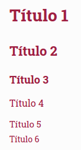

## Itálico

```
_itálico_ ou *itálico*
```

*itálico* ou *itálico*

## Negrito

```
__negrito__ ou **negrito**
```

**negrito** ou **negrito**

## Tachado

```
~~tachado~~
```

tachado

## Sobrescrito

```
texto^sobrescrito^
```

texto<sup>sobrescrito</sup>

## Parágrafo

```
Parágrafo

Novo parágrafo
```

Parágrafo

Novo parágrafo

```
Parágrafo
Novo parágrafo
```

Parágrafo  
Novo parágrafo

## Lista Não-Ordenada

```
- Primeiro item
- Segundo item
- Terceiro item
```

- Primeiro item
- Segundo item
- Terceiro item

## Lista Ordenada

```
1. Primeiro item
2. Segundo item
3. Terceiro item
```

1. Primeiro item
2. Segundo item
3. Terceiro item

## Lista com Sublista

Usa-se quatro espaços(duas vezes a tecla TAB) abaixo de um item para criar um sub-item:

```
1. Item
    - Um sub-item
    - Outro sub-item
```

1. Item
   - Um sub-item
   - Outro sub-item

## Tabela

Para gerar uma tabela, são usados ao menos 3 `---` para separar o nome da coluna das linhas e `|` para delimitar as colunas, sempre mantendo a identação como a seguir.

```
Cabeçalho | Cabeçalho 2
--------- | -------------
Célula    | Célula 2
Célula 3  | Célula 4
```

| Cabeçalho | Cabeçalho 2 |
| --- | --- |
| Célula | Célula 2 |
| Célula 3 | Célula 4 |

Para alinhar as colunas:

. Alinhar à esquerda: `:---`;  
. Alinhar ao centro: `:---:`;  
. Alinhar à direita: `---:`.

```
 Esquerda | Centro      | Direita
:-------- | :----------:| ----------:
  Célula  | Célula      | Célula
```

| Esquerda | Centro | Direita |
| --- | --- | --- |
| Célula | Célula | Célula |

## Link

Para um link usa-se a seguinte sintaxe:

```
[nome do link](endereço do link)
[Site do PET](https://pet-estatistica.github.io/site/)
```

Se quiser que o nome do link seja ele próprio:

```
https://pet-estatistica.github.io/site/
```

https://pet-estatistica.github.io/site/

Pode ser um link com título, que é o nome que aparece se o cursor for deixado em cima do link:

```
[Link com título](https://pet-estatistica.github.io/site/ "Site do PET")
```

[Link com título](https://pet-estatistica.github.io/site/)

No caso em que se sabe que um link será usado mais vezes num mesmo documento ou por comodidade, é possível escrever o link no fim do documento `[tag do link]: link` e chamá-lo no meio do documento da seguinte maneira:

```
site da UFPR [aqui][UFPR]

         ...

...fim do documento...
[UFPR]: http://www.ufpr.br/portalufpr/
```

site da UFPR [aqui](http://www.ufpr.br/portalufpr/)

## Imagem

Para usar uma imagem da web:

```r
#![legenda da imagem](link da imagem)
#![Logo do R](http://developer.r-project.org/Logo/Rlogo-5.png)
```

Logo do R

Para usar uma imagem do computador:

```
![legenda da imagem](/caminho/da/imagem.png)
```

[figure not shown]

legenda da imagem

Imagens também podem ser referenciadas como os links:

```
![Imagem referenciada][imagem]

         ...

...fim do documento...
[imagem]: http://developer.r-project.org/Logo/Rlogo-5.png
```

Imagem referenciada

É possível colocar parâmetros na imagem. Como exemplo o símbolo do R será aumentado e reduzido:

[figure not shown]

Imagem Aumentada

Imagem redizida

É possível fazer com que uma imagem contenha um link:

```
[![legenda da imagem](caminho da imagem)](link)
```

[figure not shown]

## Citação em Bloco

```
> citação de alguma frase impactante de autor famoso
e bem conceituado.
```

> citação de alguma frase impactante de autor famoso e bem conceituado.

Também pode ser em níveis como nos títulos:

```
> citação nível 1

>> citação nível 2

>>> citação nível 3
```

> citação nível 1

> > citação nível 2

> > > citação nível 3

## Ancoragem Interna

É possível ancorar num documento *markdown* como é feito em um *HTML* da seguinte maneira:

```
[pular para lista com sublista](#lista-com-sublista)
```

pular para lista com sublista

Mas existem restrições. o nome da seção ou subseção que se quer ancorar deve ser precedida de uma `#`, ser escrita em caixa baixa, se tiver mais que uma palavra elas devem ser separadas por `-` e não funcionará se tiver caracteres especiais, como `~`, `^` e `ç`. Este problema pode ser contornado ignorando caracteres especiais. Como exemplo, vamos ancorar a *Introdução*:

```
Primeiro título^[1](#introducao)^
```

Primeiro título<sup>1</sup>

# Criando um Documento Dinâmico

O primeiro passo é instalar o pacote `rmarkdown`:

```
install.packages("rmarkdown")
```

## Cabeçalho

O cabeçalho do seu documento que terá os metadados que controlarão a formatação do documento e é feito no formato *YAMl* num estilo lista aninhada delimitada por `---`, como no exemplo a seguir:

```
title: "Título do Documento"
author: "Nome do Autor"
date: "20 de maio, 2019"
output: html_document
```

Com algumas variações e mais opções:

```
title: "Título do Documento"
author:                         # No caso de ter mais de um autor
- Autor 1
- Autor 2
- Autor 3
date: r Sys.Date() entre "``" # Para pegar automaticamente a data do computador
output:          # No caso de se ter opções para o formato do output
  pdf_document
    fontsize: 11pt        # Muda o tamanho da fonte
    highlight: "zenburn"  # A forma que os textos destacados aparecerão
    number_sections: true # Numerar as seções
    toc: TRUE             # Adiciona um sumário ao documento
    toc_depth: 2          # O número mínimo de '#' para gerar um item no sumário
```

**OBS**: dependendo do tipo de output, algumas opções não funcionarão.

**OBS2**: A identações são muito importantes.

## Chunks e Códigos em Linha

Chunks de código são ambientes para inserir códigos que serão executados durante a compilação do documento e o mesmo pode ser feito com código em linha.

##### Sintaxe do chunk

```r
paste("Olá Mundo!")
```

```
## [1] "Olá Mundo!"
```

##### Sintaxe do código em linha

Olá Mundo!

Também existem opções de chunk:

- `echo =`:
  - `TRUE` o código fonte será mostrado no documento final;
  - `FALSE` o códico fonte é omitido do documento final.

```r
paste("Olá Mundo!")
```

```
## [1] "Olá Mundo!"
```

- `results =`:
  - `hide` os outputs do código serão omitodos do documento final;
  - `hold` os outputs do chunk serão mostrado somente ao final do chunk;
  - `asis` os outputs não serão formatados para o documento final;
  - `markup` marca os outputs.

```r
paste("Olá Mundo!")
```

[1] “Olá Mundo!”

Podem ser usadas mais que uma opção de chunk ao mesmo tempo, basta separa-las por `,`.

Para maia opções de preâmbulo e chunk, segue o [Guia de Referência](https://www.rstudio.com/wp-content/uploads/2015/03/rmarkdown-reference.pdf)

## Exemplo

Vamos a um pequeno exemplo de como funciona o dinamismo do *RMarkdown*. Usando uma base de dados serão oferecidas diferentes respostas baseadas nas médias dos dados e também uma breve análise exploratória com um gráfico e uma tabela.

Criando a base, objetos e tabela a serem usadas:

```r
x <- c(1,2,3,4,5,6,7,8)
y <- c(-1,-2,-3,4,-5,6,7,-8)
dados <- data.frame(var1 = x, var2 = y)
mvar1 <- mean(dados$var1)
mvar2 <- mean(dados$var2)
teste <- function(x){
  if(x > 0){
    out <- "tem média maior que zero"
  }
  else{
    out <- "tem média menor que zero"
  }
  return(out)
}
tab <- kableExtra::kable(dados, format = "markdown")
```

Primeiramente mostrando a tabela:

| var1 | var2 |
| --- | --- |
| 1 | -1 |
| 2 | -2 |
| 3 | -3 |
| 4 | 4 |
| 5 | -5 |
| 6 | 6 |
| 7 | 7 |
| 8 | -8 |

Tabela criada para o formato Markdown para ser mostrada com código em linha para chamar o objeto `tab`.

Vamos ao gráfico:

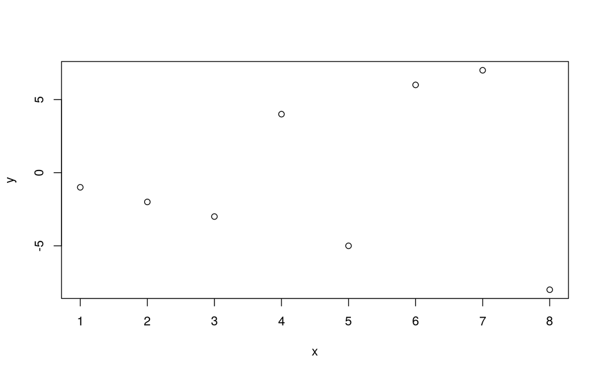

```r
plot(y ~ x)
```

Para gerar respostas baseadas em objetos e resultados:

A variável var1 tem média maior que zero com o valor de 4.5.

A variável var2 tem média menor que zero com o valor de -0.25.

Para gerar essas frases foi usada a seguinte sintaxe:

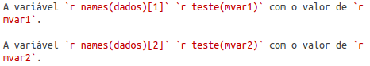

# Referências

http://www.leg.ufpr.br/~fernandomayer/palestra/useR-2015/Rmarkdown-rautu.html#como_a_ci%C3%AAncia_funciona

https://rmarkdown.rstudio.com

https://github.com/adam-p/markdown-here/wiki/Markdown-Cheatsheet

https://www.rstudio.com/wp-content/uploads/2015/02/rmarkdown-cheatsheet.pdf

http://www.leg.ufpr.br/~walmes/cursoR/guia_rapido_R.pdf

[figure not shown]

Jayme Gomes dos Santos Junior

03 de outubro de 2019